# Publications

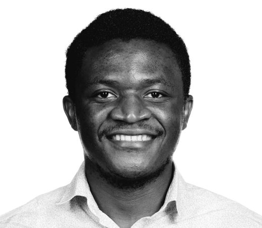

Patrik Kenfack

PhD Candidate,  
Computer Science

# Publications

Journal, conference and workshop papers. Every title opens a page with the abstract and all of the paper’s links. The full list, with citation counts, is on Google Scholar.

## 2025

1. JournalWorkshopSpotlight oral

### Towards Fair In-Context Learning with Tabular Foundation Models

   **Patrik Joslin Kenfack**, Samira Ebrahimi Kahou, Ulrich Aïvodji

   Transactions on Machine Learning Research · 1st ICML Workshop on Foundation Models for Structured Data

   [Paper](https://openreview.net/forum?id=91SqyYQjiN)[Code](https://github.com/tisl-lab/FairTabICL)Blog
2. Workshop

### GradTune: Last-layer Fine-tuning for Group Robustness Without Group Annotation

   **Patrik Joslin Kenfack**, Ulrich Aïvodji, Samira Ebrahimi Kahou

   ICLR Workshop on Spurious Correlation and Shortcut Learning: Foundations and Solutions

   [Paper](https://openreview.net/pdf?id=WL9Sxi3iat)[PDF](https://openreview.net/pdf?id=WL9Sxi3iat)
3. Workshop

### Towards personalized healthcare without harm via bias modulation

   Frank Ngaha, **Patrik Joslin Kenfack**, Ulrich Aïvodji, Samira Ebrahimi Kahou

   ICLR Workshop on Spurious Correlation and Shortcut Learning: Foundations and Solutions

   [Paper](https://openreview.net/pdf?id=DBQ0b5JTxk)[PDF](https://openreview.net/pdf?id=DBQ0b5JTxk)

## 2024

1. Journal🏆 Best paper runner-up

### Fairness Under Demographic Scarce Regime

   **Patrik Joslin Kenfack**, Samira Ebrahimi Kahou, Ulrich Aïvodji

   Transactions on Machine Learning Research

   [Paper](https://openreview.net/forum?id=TB18G0w6Ld)[PDF](https://openreview.net/pdf?id=TB18G0w6Ld)[Code](https://github.com/tisl-lab/fair-dsr)[Video](https://www.youtube.com/watch?v=dLMC1IbR4LA)
2. Journal

### A Survey on Fairness Without Demographics

   **Patrik Joslin Kenfack**, Samira Ebrahimi Kahou, Ulrich Aïvodji

   Transactions on Machine Learning Research

   [Paper](https://openreview.net/forum?id=3HE4vPNIfX)[PDF](https://openreview.net/pdf?id=3HE4vPNIfX)
3. Workshop

### Adaptive Group Robust Ensemble Knowledge Distillation

   **Patrik Joslin Kenfack**, Ulrich Aïvodji, Samira Ebrahimi Kahou

   NeurIPS Algorithmic Fairness through the lens of Metrics and Evaluation Workshop

   [PDF](https://arxiv.org/pdf/2411.14984)